# Moodbar stats

```
data = np.loadtxt("./feedbacks_distribution.tsv", skiprows=1)
```

```
import numpy as np
```

```
data = np.loadtxt("./feedbacks_distribution.tsv", skiprows=1)
```

```
print data
```

```
[ 1.  1.  1. ...,  1.  1.  1.]
```

Let us open the file `data/feedbacks_distribution.tsv`:

How many observations do we have?

```
print "number of observations N = %d" % len(data)
```

```
print "number of observations N = %d" % len(data)
```

```
number of observations N = 17414
```

What is the average feedbacks count?

```
print "average feedback count = %g" % np.mean(data)
```

```
print "average feedback count = %g" % np.mean(data)
```

```
average feedback count = 1.55214
```

```
print "standard deviation = %g" % np.std(data)
```

```
print "standard deviation = %g" % np.std(data)
```

```
standard deviation = 45.9751
```

What is the range of the data?

```
print "data range = %d" % data.ptp()
```

```
print "data range = %d" % data.ptp()
```

```
data range = 6041
```

There is a huge overdispersion! Let us look at the histogram of the data

```
import matplotlib.pyplot as pp
```

```
import matplotlib.pyplot as pp
```

```
pp.hist(data, bins=data.ptp())
```

```
pp.xlabel('counts')
```

```
pp.ylabel('frequency')
```

```
pp.title('moodbar feedbacks')
```

```
pp.show()
```

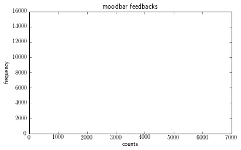

This is completely unreadable. Let us try with a log-linear histogram..

```
pp.hist(data, bins=data.ptp(), log=1)
```

```
pp.hist(data, bins=data.ptp(), log=1)
```

```
pp.xlabel('counts')
```

```
pp.ylabel('frequency')
```

```
pp.title('moodbar feedbacks')
```

```
pp.show()
```

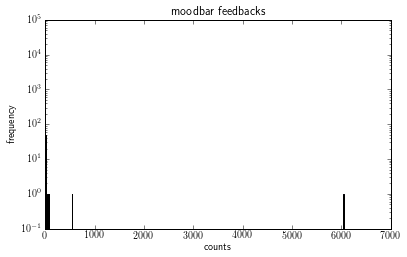

As expected, we have a few outliers which completely skew the histograms. Let us more carefully at the head of the distribution

```
pp.hist(data, bins=data.ptp(), log=1)
```

```
pp.hist(data, bins=data.ptp(), log=1)
```

```
pp.xlabel('counts')
```

```
pp.ylabel('frequency')
```

```
pp.title('moodbar feedbacks')
```

```
pp.xlim(0,100)
```

```
pp.show()
```

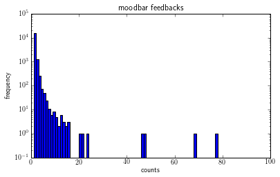

This starts to be meaningful. We see that up to $n = 16$ (roughly) we have more than one count per bin. For $n\gt 20$ we see that we have single outliers. We could therefore filter out the data at that cutoff, or filter out the bins that have only one observation

[output not shown]

```
hist, bin_edges = np.histogram(data, bins=data.ptp())
```

```
values, = np.nonzero(hist > 1)
```

```
tmp = []
```

```
for v, h in zip(values, hist[hist>1]):
```

```
    tmp.extend([v+1]*h)
```

```
data = np.asarray(tmp)
```

```
pp.hist(data, bins=data.ptp(), log=1, normed=1)
```

```
pp.xlabel('counts')
```

```
pp.ylabel('frequency')
```

```
pp.title('moodbar feedbacks (filtered)')
```

```
pp.show()
```

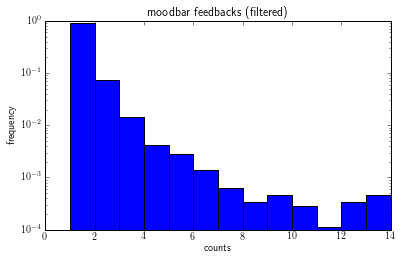

We can see if the distribution follow a geometric law. The geometric law has parameter $p$ and the probability of seeing a particular value $k$ is given by $p(k) = (1-p)^{k-1}p$

```
print 'p = %g' % ph
```

```
ph = float(len(data))/data.sum()
```

```
print 'p = %g' % ph
```

```
p = 0.864329
```

```
pp.show()
```

```
from scipy.stats import geom
```

```
rv = geom(ph)
```

```
x = np.arange(1, data.ptp())
```

```
pp.hist(data, bins=data.ptp(), fc='none', log=1, normed=1, label='data')
```

```
pp.xlabel('counts')
```

```
pp.ylabel('frequency')
```

```
pp.title('moodbar feedbacks (filtered)')
```

```
pp.plot(x+0.5, rv.pmf(x),'o k', label='geometric fit', hold=1)
```

```
pp.legend()
```

```
pp.show()
```

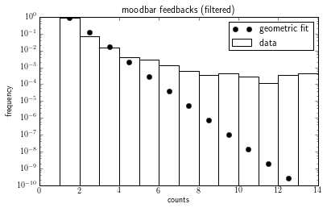

We can see that the geometric distribution badly underestimates the counts in tail of the distribution. What about Zipf's law then? This is the discrete equivalent of the power-law distribution. To estimate the exponent, we numerically minimize the log-likelihood.

[output not shown]

```
from scipy.stats import zipf
```

```
nll = lambda x : - zipf(x).logpmf(data).sum()
```

```
from scipy.optimize import fmin
```

```
sh = fmin(nll, (1,))
```

```
print "estimated exponent s = %g" % sh
```

```
Optimization terminated successfully.
         Current function value: 7297.102579
         Iterations: 19
         Function evaluations: 38
estimated exponent s = 3.66563
```

```
pp.show()
```

```
pp.hist(data, bins=data.ptp(), fc='none', log=1, normed=1, label='data')
```

```
pp.xlabel('counts')
```

```
pp.ylabel('frequency')
```

```
pp.title('moodbar feedbacks (filtered)')
```

```
pp.plot(x+0.5, zipf(sh).pmf(x),'o k', label='Zipf\'s law fit', hold=1)
```

```
pp.legend()
```

```
pp.show()
```

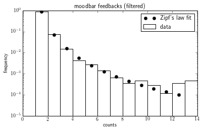

This is great! The fit looks very promising! The next step is to perform a real form of hypothesis testing. For now, we have a very strong candidate of the distributional form of the mood feedback data.